# Practical Machine Learning Final Project - Motion Classification

#### Nov 9, 2018

## **Introduction**

### **Background**

Using devices such as Jawbone Up, Nike FuelBand, and Fitbit it is now possible to collect a large amount of data about personal activity relatively inexpensively. These type of devices are part of the quantified self movement – a group of enthusiasts who take measurements about themselves regularly to improve their health, to find patterns in their behavior, or because they are tech geeks. One thing that people regularly do is quantify how much of a particular activity they do, but they rarely quantify how well they do it. In this project, your goal will be to use data from accelerometers on the belt, forearm, arm, and dumbell of 6 participants. They were asked to perform barbell lifts correctly and incorrectly in 5 different ways. More information is available from the website here: http://groupware.les.inf.puc-rio.br/har (see the section on the Weight Lifting Exercise Dataset).

### **Data**

The training data for this project are available here: https://d396qusza40orc.cloudfront.net/predmachlearn/pml-training.csv.

The test data are available here: https://d396qusza40orc.cloudfront.net/predmachlearn/pml-testing.csv.

Participants were asked to perform one set of 10 repetitions of the Unilateral Dumbbell Biceps Curl in five different fashions: exactly according to the specification (Class A), **throwing the elbows to the front (Class B)**, **lifting the dumbbell only halfway (Class C)**, **lowering the dumbbell only halfway (Class D)** and **throwing the hips to the front (Class E)**. **Class A corresponds to the specified execution of the exercise, while the other 4 classes correspond to common mistakes**. Participants were supervised by an experienced weight lifter to make sure the execution complied to the manner they were supposed to simulate. The exercises were performed by six male participants aged between 20-28 years, with little weight lifting experience. We made sure that all participants could easily simulate the mistakes in a safe and controlled manner by using a relatively light dumbbell (1.25kg).

More informnation for this project come from this source http://groupware.les.inf.puc-rio.br/har.

## **Objective**

One thing that people regularly do is quantify how much of a particular activity they do, but they rarely quantify how well they do it. In this project, the goal will be to use data from accelerometers on the belt, forearm, arm, and dumbell of 6 participants. This is the “classe” variable in the training set. I can use any of the other variables to predict with, and create a report describing how I built your model, how I used cross validation, what I think the expected out of sample error is, and why I made the choices you did. I will also use the prediction model to predict 20 different test cases.

## **Preprocessing**

Let’s load the train and test data into environment.

```r
train_file_name <- "pml-training.csv"
test_file_name <- "pml-testing.csv"
train_url <- "https://d396qusza40orc.cloudfront.net/predmachlearn/pml-training.csv"
test_url <- "https://d396qusza40orc.cloudfront.net/predmachlearn/pml-testing.csv"
# Check if the data is downloaded and download when applicable
if (!file.exists(train_file_name)) {
    download.file(train_url, destfile = train_file_name )
}
if (!file.exists(test_file_name)) {
    download.file(test_url, destfile = test_file_name )
}
train_data <- read.csv(train_file_name)
test_data <- read.csv(test_file_name)
```

Train-Test data has been loaded, let’s see how many cases in total.

```r
dim(train_data)
```

```
## [1] 19622   160
```

```r
dim(test_data)
```

```
## [1]  20 160
```

Total 19622 cases are collected for training and 20 cases for test with 159 predictors to predict “classe” variable.  
Now, let’s see the stucture of training data.

```r
str(train_data)
```

```
## 'data.frame':    19622 obs. of  160 variables:
##  $ X                       : int  1 2 3 4 5 6 7 8 9 10 ...
##  $ user_name               : Factor w/ 6 levels "adelmo","carlitos",..: 2 2 2 2 2 2 2 2 2 2 ...
##  $ raw_timestamp_part_1    : int  1323084231 1323084231 1323084231 1323084232 1323084232 1323084232 1323084232 1323084232 1323084232 1323084232 ...
##  $ raw_timestamp_part_2    : int  788290 808298 820366 120339 196328 304277 368296 440390 484323 484434 ...
##  $ cvtd_timestamp          : Factor w/ 20 levels "02/12/2011 13:32",..: 9 9 9 9 9 9 9 9 9 9 ...
##  $ new_window              : Factor w/ 2 levels "no","yes": 1 1 1 1 1 1 1 1 1 1 ...
##  $ num_window              : int  11 11 11 12 12 12 12 12 12 12 ...
##  $ roll_belt               : num  1.41 1.41 1.42 1.48 1.48 1.45 1.42 1.42 1.43 1.45 ...
##  $ pitch_belt              : num  8.07 8.07 8.07 8.05 8.07 8.06 8.09 8.13 8.16 8.17 ...
##  $ yaw_belt                : num  -94.4 -94.4 -94.4 -94.4 -94.4 -94.4 -94.4 -94.4 -94.4 -94.4 ...
##  $ total_accel_belt        : int  3 3 3 3 3 3 3 3 3 3 ...
##  $ kurtosis_roll_belt      : Factor w/ 397 levels "","-0.016850",..: 1 1 1 1 1 1 1 1 1 1 ...
##  $ kurtosis_picth_belt     : Factor w/ 317 levels "","-0.021887",..: 1 1 1 1 1 1 1 1 1 1 ...
##  $ kurtosis_yaw_belt       : Factor w/ 2 levels "","#DIV/0!": 1 1 1 1 1 1 1 1 1 1 ...
```

[output cut: 86 more lines]

Many missing values were collected into data. Let’s see total number of missing datas in dataset.

```r
sapply(train_data, function(x) sum(x == "" | is.na(x)))
```

```
##                        X                user_name     raw_timestamp_part_1
##                        0                        0                        0
##     raw_timestamp_part_2           cvtd_timestamp               new_window
##                        0                        0                        0
##               num_window                roll_belt               pitch_belt
##                        0                        0                        0
##                 yaw_belt         total_accel_belt       kurtosis_roll_belt
##                        0                        0                    19216
##      kurtosis_picth_belt        kurtosis_yaw_belt       skewness_roll_belt
##                    19216                    19216                    19216
##     skewness_roll_belt.1        skewness_yaw_belt            max_roll_belt
##                    19216                    19216                    19216
##           max_picth_belt             max_yaw_belt            min_roll_belt
##                    19216                    19216                    19216
##           min_pitch_belt             min_yaw_belt      amplitude_roll_belt
##                    19216                    19216                    19216
##     amplitude_pitch_belt       amplitude_yaw_belt     var_total_accel_belt
##                    19216                    19216                    19216
##            avg_roll_belt         stddev_roll_belt            var_roll_belt
##                    19216                    19216                    19216
##           avg_pitch_belt        stddev_pitch_belt           var_pitch_belt
##                    19216                    19216                    19216
##             avg_yaw_belt          stddev_yaw_belt             var_yaw_belt
##                    19216                    19216                    19216
##             gyros_belt_x             gyros_belt_y             gyros_belt_z
##                        0                        0                        0
##             accel_belt_x             accel_belt_y             accel_belt_z
##                        0                        0                        0
##            magnet_belt_x            magnet_belt_y            magnet_belt_z
##                        0                        0                        0
##                 roll_arm                pitch_arm                  yaw_arm
##                        0                        0                        0
##          total_accel_arm            var_accel_arm             avg_roll_arm
##                        0                    19216                    19216
##          stddev_roll_arm             var_roll_arm            avg_pitch_arm
##                    19216                    19216                    19216
##         stddev_pitch_arm            var_pitch_arm              avg_yaw_arm
##                    19216                    19216                    19216
##           stddev_yaw_arm              var_yaw_arm              gyros_arm_x
##                    19216                    19216                        0
```

[output cut: 53 more lines]

```
##                    19216                        0                    19216
##         avg_roll_forearm      stddev_roll_forearm         var_roll_forearm
##                    19216                    19216                    19216
##        avg_pitch_forearm     stddev_pitch_forearm        var_pitch_forearm
##                    19216                    19216                    19216
##          avg_yaw_forearm       stddev_yaw_forearm          var_yaw_forearm
##                    19216                    19216                    19216
##          gyros_forearm_x          gyros_forearm_y          gyros_forearm_z
##                        0                        0                        0
##          accel_forearm_x          accel_forearm_y          accel_forearm_z
##                        0                        0                        0
##         magnet_forearm_x         magnet_forearm_y         magnet_forearm_z
##                        0                        0                        0
##                   classe
##                        0
```

It shows that many variable has missing 19216 datas. Since there is too many missing data compared to full training data, I decided not to consider those variables in model. Let’s see what those variables are.

```r
findNonPredictors <- function (data) {
    x <- sapply(data, function(x) sum(x == "" | is.na(x)))
    l <- c()
    for (i in 1:length(x)) {
        if (x[[i]] != 0) {l <- c(l, i)}
    }
    return (l)
}
length(findNonPredictors(train_data))
```

```
## [1] 100
```

In total, 100 variables has large amount of missing datas. The reason for the large amount of missing values is unknown, but the rest of data is efficient enought to predict “classe” variable.  
Let’s create training set without those variables.

```r
library(caret)
NotPredictors <- findNonPredictors(train_data)
training <- train_data[,-NotPredictors]
testing <- test_data[,-NotPredictors]
```

Now, the first few variables seem to be informatic. The first variable, X, is merely index of each cases, and user_name is the name of 6 participants, and rest few variables indicated when and how participants were involved in this experiments. Hence, I will not include first 7 variables in the model as well.

```r
training <- training[,-(1:7)]
testing <-  testing[,-(1:7)]
```

Now, training data contains only necessary variables to modelling. Let’s see the sumamry of training data.

```r
summary(training)
```

```
##    roll_belt        pitch_belt          yaw_belt       total_accel_belt
##  Min.   :-28.90   Min.   :-55.8000   Min.   :-180.00   Min.   : 0.00
##  1st Qu.:  1.10   1st Qu.:  1.7600   1st Qu.: -88.30   1st Qu.: 3.00
##  Median :113.00   Median :  5.2800   Median : -13.00   Median :17.00
##  Mean   : 64.41   Mean   :  0.3053   Mean   : -11.21   Mean   :11.31
##  3rd Qu.:123.00   3rd Qu.: 14.9000   3rd Qu.:  12.90   3rd Qu.:18.00
##  Max.   :162.00   Max.   : 60.3000   Max.   : 179.00   Max.   :29.00
##   gyros_belt_x        gyros_belt_y       gyros_belt_z
##  Min.   :-1.040000   Min.   :-0.64000   Min.   :-1.4600
##  1st Qu.:-0.030000   1st Qu.: 0.00000   1st Qu.:-0.2000
##  Median : 0.030000   Median : 0.02000   Median :-0.1000
##  Mean   :-0.005592   Mean   : 0.03959   Mean   :-0.1305
##  3rd Qu.: 0.110000   3rd Qu.: 0.11000   3rd Qu.:-0.0200
##  Max.   : 2.220000   Max.   : 0.64000   Max.   : 1.6200
##   accel_belt_x       accel_belt_y     accel_belt_z     magnet_belt_x
##  Min.   :-120.000   Min.   :-69.00   Min.   :-275.00   Min.   :-52.0
##  1st Qu.: -21.000   1st Qu.:  3.00   1st Qu.:-162.00   1st Qu.:  9.0
##  Median : -15.000   Median : 35.00   Median :-152.00   Median : 35.0
##  Mean   :  -5.595   Mean   : 30.15   Mean   : -72.59   Mean   : 55.6
##  3rd Qu.:  -5.000   3rd Qu.: 61.00   3rd Qu.:  27.00   3rd Qu.: 59.0
##  Max.   :  85.000   Max.   :164.00   Max.   : 105.00   Max.   :485.0
##  magnet_belt_y   magnet_belt_z       roll_arm         pitch_arm
##  Min.   :354.0   Min.   :-623.0   Min.   :-180.00   Min.   :-88.800
##  1st Qu.:581.0   1st Qu.:-375.0   1st Qu.: -31.77   1st Qu.:-25.900
##  Median :601.0   Median :-320.0   Median :   0.00   Median :  0.000
##  Mean   :593.7   Mean   :-345.5   Mean   :  17.83   Mean   : -4.612
##  3rd Qu.:610.0   3rd Qu.:-306.0   3rd Qu.:  77.30   3rd Qu.: 11.200
##  Max.   :673.0   Max.   : 293.0   Max.   : 180.00   Max.   : 88.500
##     yaw_arm          total_accel_arm  gyros_arm_x        gyros_arm_y
##  Min.   :-180.0000   Min.   : 1.00   Min.   :-6.37000   Min.   :-3.4400
##  1st Qu.: -43.1000   1st Qu.:17.00   1st Qu.:-1.33000   1st Qu.:-0.8000
##  Median :   0.0000   Median :27.00   Median : 0.08000   Median :-0.2400
##  Mean   :  -0.6188   Mean   :25.51   Mean   : 0.04277   Mean   :-0.2571
##  3rd Qu.:  45.8750   3rd Qu.:33.00   3rd Qu.: 1.57000   3rd Qu.: 0.1400
##  Max.   : 180.0000   Max.   :66.00   Max.   : 4.87000   Max.   : 2.8400
##   gyros_arm_z       accel_arm_x       accel_arm_y      accel_arm_z
##  Min.   :-2.3300   Min.   :-404.00   Min.   :-318.0   Min.   :-636.00
##  1st Qu.:-0.0700   1st Qu.:-242.00   1st Qu.: -54.0   1st Qu.:-143.00
##  Median : 0.2300   Median : -44.00   Median :  14.0   Median : -47.00
##  Mean   : 0.2695   Mean   : -60.24   Mean   :  32.6   Mean   : -71.25
```

[output cut: 50 more lines]

```
##  Max.   :311.00000   Max.   :231.0000   Max.   : 477.00   Max.   : 923.0
##  accel_forearm_z   magnet_forearm_x  magnet_forearm_y magnet_forearm_z
##  Min.   :-446.00   Min.   :-1280.0   Min.   :-896.0   Min.   :-973.0
##  1st Qu.:-182.00   1st Qu.: -616.0   1st Qu.:   2.0   1st Qu.: 191.0
##  Median : -39.00   Median : -378.0   Median : 591.0   Median : 511.0
##  Mean   : -55.29   Mean   : -312.6   Mean   : 380.1   Mean   : 393.6
##  3rd Qu.:  26.00   3rd Qu.:  -73.0   3rd Qu.: 737.0   3rd Qu.: 653.0
##  Max.   : 291.00   Max.   :  672.0   Max.   :1480.0   Max.   :1090.0
##  classe
##  A:5580
##  B:3797
##  C:3422
##  D:3216
##  E:3607
##
```

Now, let’s see the correlation of each predictors and figure out whether we need all 52 variables to predict “classe” variable.

```r
M <- cor(training[,-53])
diag(M) <- 0
which(abs(M) >= 0.9, arr.ind = T)
```

```
##                  row col
## total_accel_belt   4   1
## accel_belt_y       9   1
## accel_belt_z      10   1
## accel_belt_x       8   2
## roll_belt          1   4
## accel_belt_y       9   4
## accel_belt_z      10   4
## pitch_belt         2   8
## roll_belt          1   9
## total_accel_belt   4   9
## accel_belt_z      10   9
## roll_belt          1  10
## total_accel_belt   4  10
## accel_belt_y       9  10
## gyros_arm_y       19  18
## gyros_arm_x       18  19
## gyros_dumbbell_z  33  31
## gyros_forearm_z   46  31
## gyros_dumbbell_x  31  33
## gyros_forearm_z   46  33
## gyros_dumbbell_x  31  46
## gyros_dumbbell_z  33  46
```

It shows that there are few highly correlated data. columnns of (1,4), (1,9), (1,10),(4,9), (31,33), (33, 46), (31, 46) and etc. Let’s see few correlation plot.

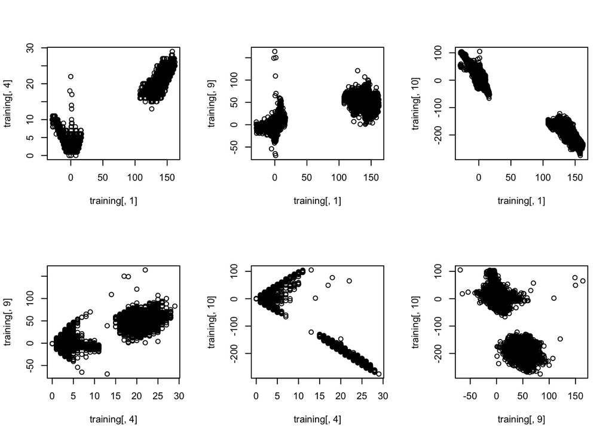

```r
par(mfrow = c(2,3))
plot(training[,1],training[,4])
plot(training[,1],training[,9])
plot(training[,1],training[,10])
plot(training[,4],training[,9])
plot(training[,4],training[,10])
plot(training[,9],training[,10])
```

As I expected, 1,4,9,10th predictors are highly correlated, but there is no significant outliers. Let’s see the rest of the correlation plot.

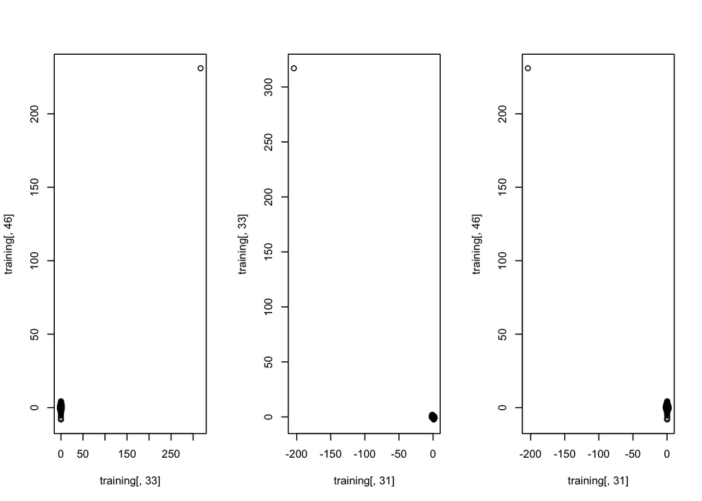

```r
par(mfrow = c(1,3))
plot(training[,33],training[,46])
plot(training[,31],training[,33])
plot(training[,31],training[,46])
```

We can see most of the points concentrated at (0,0), but there is one point that seems to be outlier. Let’s investigate that particular case

```r
c(which.min(training[,31]), which.max(training[,31]))
```

```
## [1]  5373 13792
```

```r
c(which.min(training[,33]), which.max(training[,33]))
```

```
## [1] 8929 5373
```

```r
c(which.min(training[,46]), which.max(training[,46]))
```

```
## [1]  941 5373
```

It seems that case 5373 needs to be investigated. let’s see how it effects rest of that. Let’s compare to mean.

```r
training[5373,c(31,33,46)]
```

```
##      gyros_dumbbell_x gyros_dumbbell_z gyros_forearm_z
## 5373             -204              317             231
```

```r
sapply(training[,c(31,33,46)], mean)
```

```
## gyros_dumbbell_x gyros_dumbbell_z  gyros_forearm_z
##        0.1610845       -0.1289889        0.1512450
```

It seems that 5373th case brings quite variability. Let’s how it makes difference by removing that case.

```r
M <- cor(training[-5373,-53])
diag(M) <- 0
which(abs(M) >= 0.9, arr.ind = T)
```

```
##                  row col
## total_accel_belt   4   1
## accel_belt_y       9   1
## accel_belt_z      10   1
## accel_belt_x       8   2
## roll_belt          1   4
## accel_belt_y       9   4
## accel_belt_z      10   4
## pitch_belt         2   8
## roll_belt          1   9
## total_accel_belt   4   9
## accel_belt_z      10   9
## roll_belt          1  10
## total_accel_belt   4  10
## accel_belt_y       9  10
## gyros_arm_y       19  18
## gyros_arm_x       18  19
```

Now, we can see that correlation between 31, 33, and 46th variables do not exceed 0.9. Let’s see the correlation of those

```r
cor(training[-5373,31], training[-5373,33])
```

```
## [1] -0.6170703
```

```r
cor(training[-5373,33], training[-5373,46])
```

```
## [1] 0.06143106
```

```r
cor(training[-5373,31], training[-5373,46])
```

```
## [1] -0.07783241
```

It seems that 31 and 33th variable are still correlated, but 33 and 46, 31 and 46 are not correlated. I believe 5373th case is recorded incorrectly so let’s discard this case in this analysis since we have almost 20k rows of data.

```r
training <- training[-5373, ]
```

Now, we removed one outlier, but some of the variables are still highly correlated. Let’s use “pca” in caret package to reduce correlation and dimensions. Also, it will also normalize the data as well.

```r
preProcValues <- preProcess(training[-53], method = "pca")
trainTrans <- predict(preProcValues, training[,-53])
testTrans <- predict(preProcValues, testing[,-53])
N <- cor(trainTrans)
diag(N) <- 0
which(abs(N) > 0.5, arr.ind = T)
```

```
##      row col
```

Now, we can see there is no correlated data. Let’s output the dimension of new uncollreated data

```r
dim(trainTrans)
```

```
## [1] 19621    26
```

```r
dim(testTrans)
```

```
## [1] 20 26
```

From 52 predictors, now we have 26 uncorrelated predictors only.

```r
trainTrans <- cbind(trainTrans, training[,53])
colnames(trainTrans)[dim(trainTrans)[2]] <- "classe"

testTrans <- cbind(testTrans, testing[,53])
colnames(testTrans)[dim(testTrans)[2]] <- "problem_id"
```

## **Modeling**

Before fitting the model, let’s set cross validation train-test split and cross validation parameters.

```r
set.seed(12315)
inTrain <- createDataPartition(y = trainTrans$classe,
                               p = 3/4, list = FALSE)
trainPart <- trainTrans[inTrain,]
testPart <- trainTrans[-inTrain,]

trControl <- trainControl(method = "repeatedcv", number = 5, repeats = 5)
```

Since this analysis is a classificaiton problem, I will use Decision Tree, Gradient Boosting, and Random Forest to train the data. The Random Forest is expected to output the highest accuracy.

```r
# Decision Tree
mod_rpart <- train(classe ~ ., data = trainPart,
                   method = "rpart", trControl = trControl)
# Stochastic Gradient Boosting
mod_gbm <- train(classe ~ ., data = trainPart,
                 method = "gbm", trControl = trControl,verbose = FALSE)
# Random Forest
mod_rf <- train(classe ~ ., data = trainPart,
                method = "rf", trControl = trControl,verbose = FALSE)
```

Let’s see the overall accuracy of the three model.

```r
# Dicision Tree
confusionMatrix(testPart$classe,predict(mod_rpart, newdata = testPart))$overall[1]
```

```
##  Accuracy
## 0.3720171
```

```r
# Gredient Boosting
confusionMatrix(testPart$classe,predict(mod_gbm, newdata = testPart))$overall[1]
```

```
##  Accuracy
## 0.8439731
```

```r
# Random Forest
confusionMatrix(testPart$classe,predict(mod_rf, newdata = testPart))$overall[1]
```

```
##  Accuracy
## 0.9928615
```

As we expected, Random Forest algorithm gives the highest accuracy. Hence, let’s use RF model to test set.

## **Prediction**

```r
pred_rf <- predict(mod_rf, newdata = testTrans)
pred_rf
```

```
##  [1] B A B A A B D B A A A C B A E E A B B B
## Levels: A B C D E
```